# part C

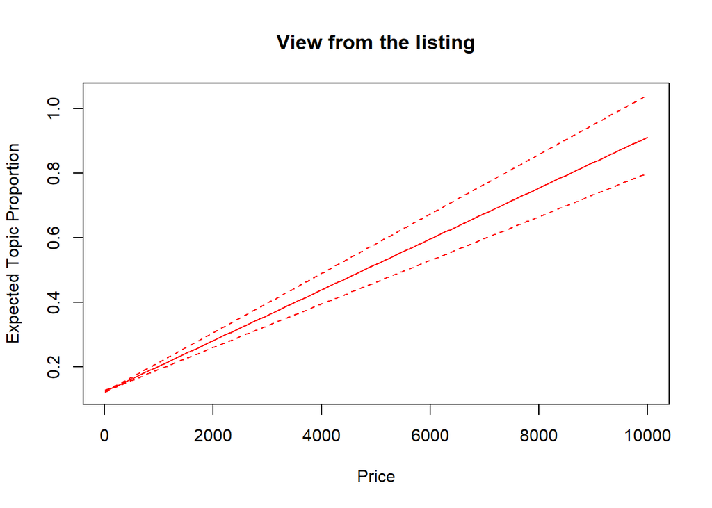

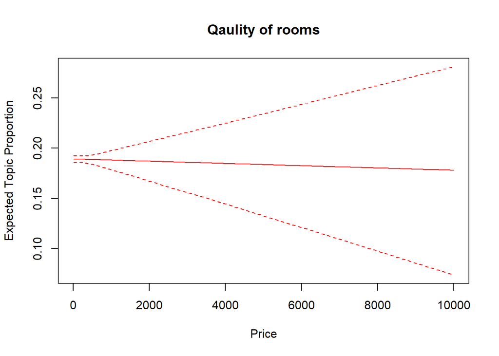

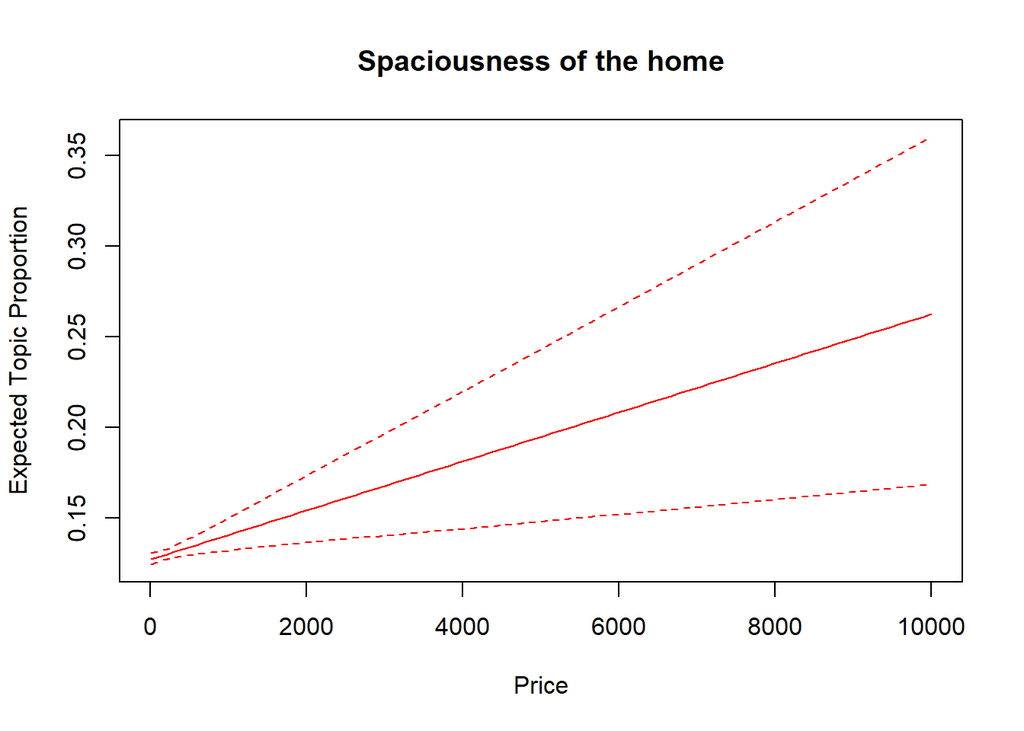

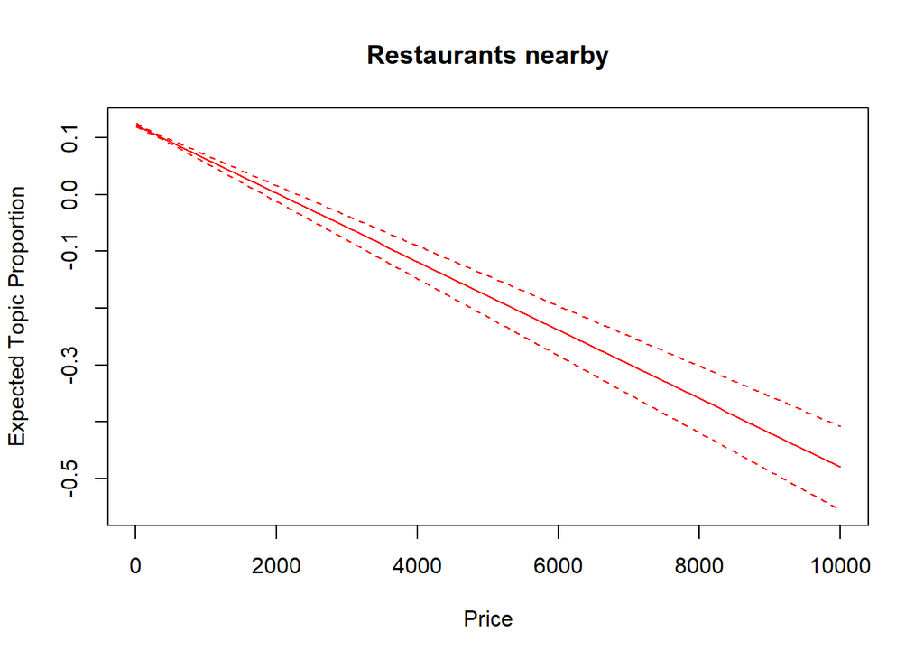

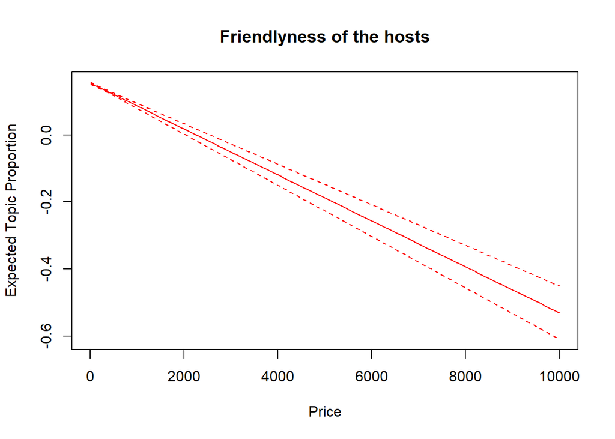

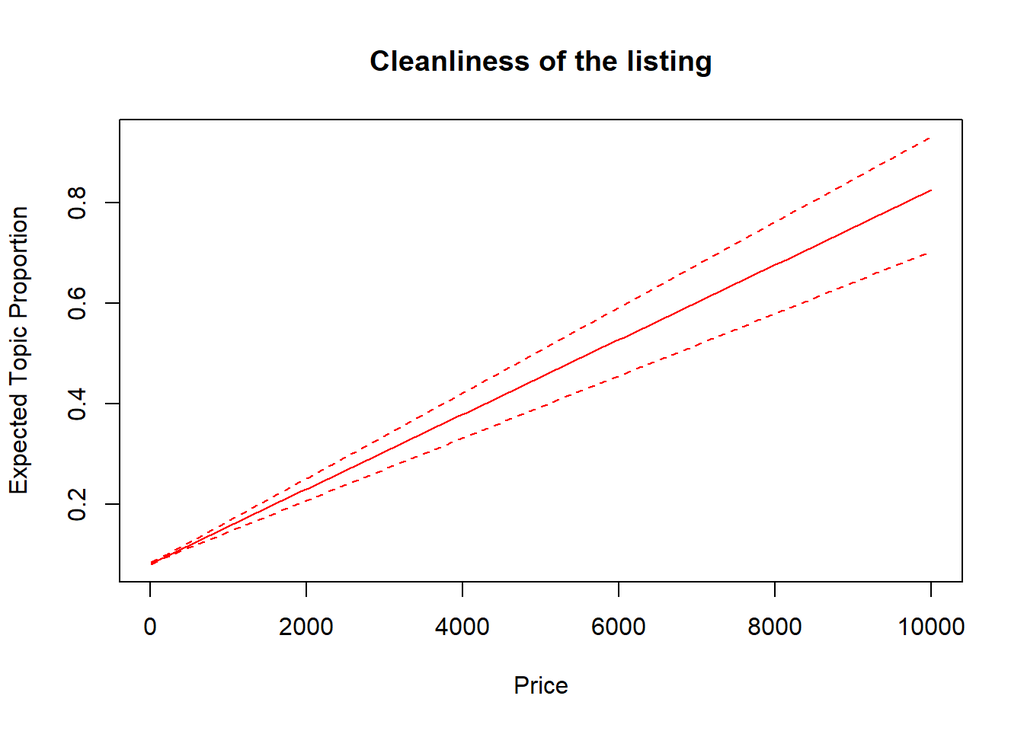

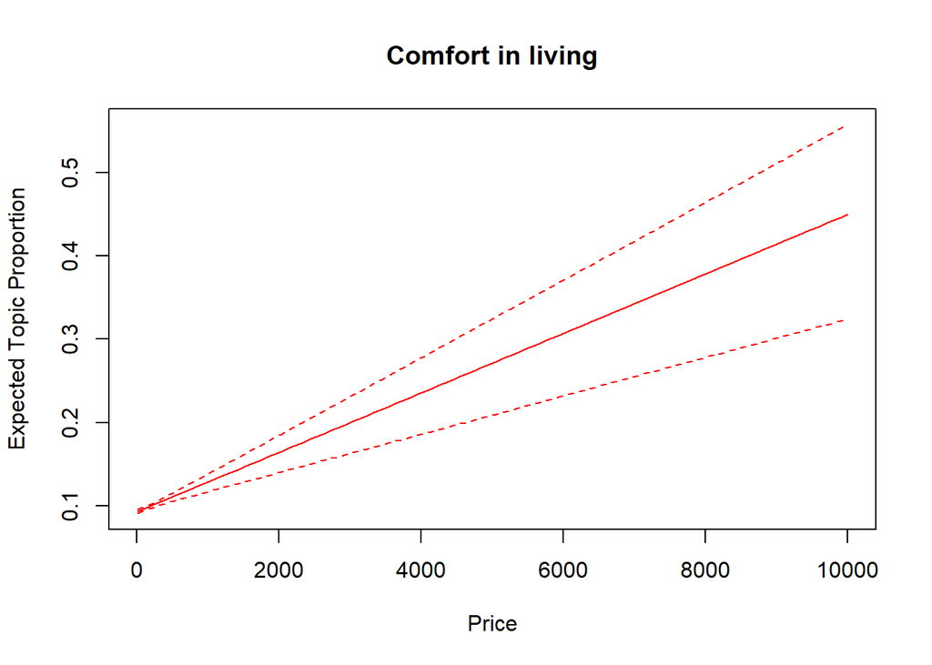

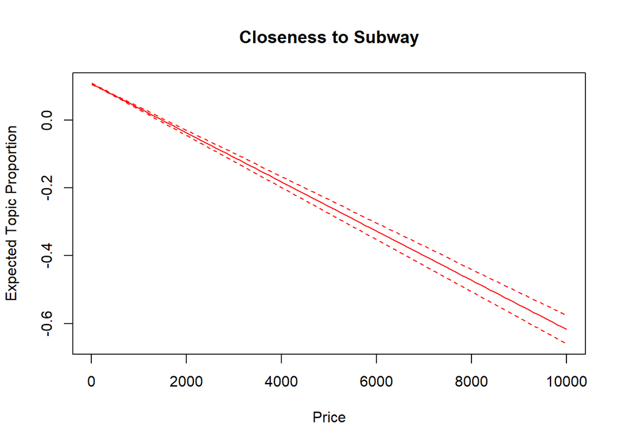

```r
# Effect of price on topic
# probability treating price as
# a continuous variable.
#
# Ploting each topic separately
# we can see that some of them increase
# substantially with the price

for(i in 1:length(topic_labels)){
plot(effects, covariate = "price",
     topics = i,
     model = airbnbfit, method = "continuous",
     # For this plotting we get the uper quantile
     # and low quantile of the price
     xlab = "Price",
     # xlim = c(0,800),
     main = topic_labels[i],
     printlegend = FALSE,
     custom.labels =topic_labels[i],
     labeltype = "custom")
}
```

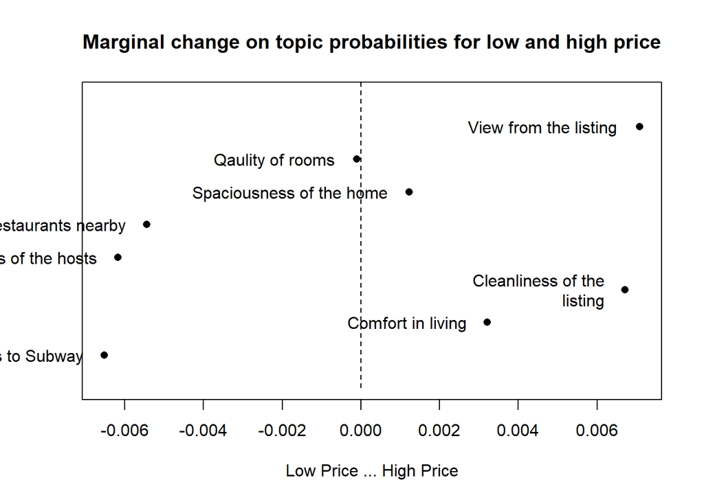

```r
# Lets also plot them as a contrast between
# the minimum and maximum price
# for that we need the margins of the upper and lower quantile
margin1 <- as.numeric(quantile(output$meta$price)[2])
margin2 <- as.numeric(quantile(output$meta$price)[4])


plot(effects, covariate = "price",
     topics = c(1:8),
     model = newyorkfit, method = "difference",
     cov.value1 = margin2, cov.value2 = margin1,
     xlab = "Low Price ... High Price",
     # xlim = c(-0.01,0.01),
     main = "Marginal change on topic probabilities for low and high price",
     custom.labels =topic_labels,
     ci.level = 0.05,
     labeltype = "custom")
```

```r
# Finding number  amenities, bathrooms,
i <- 1
for (i in 1:length(listings_detailed$host_verifications)) {

  listings_detailed$num_amenities[i] <- length(strsplit(listings_detailed$amenities[i], split= " ")[[1]])
  listings_detailed$num_bath[i] <- as.numeric(gsub("[^0-9.]", "",listings_detailed$bathrooms_text[i]))
    i <- i+1
}

all_sentiments <- readr::read_csv("sentiments.csv")

join_data <- listings_detailed %>% dplyr::select(listing_id, neighbourhood_cleansed, num_bath,num_amenities,beds, room_type)

sentiment <- all_sentiments %>% left_join(join_data)
sentiment <- sentiment %>% na.omit()
```

```r
stm_object<- newyorkfit$theta
colnames(stm_object) <- c("View from the listing", "Qaulity of rooms","Spaciousness of the home","Restaurants nearby", "Friendlyness of the hosts", "Cleanliness of the listing", "Comfort in living", "Closeness to Subway")


causal_topic_df <- cbind(output$meta,stm_object)

causal_topic_df  %>%
  left_join(sentiment) %>%
  dplyr::select(-c(listing_id, comments_grouped_listing,X1)) %>%
  na.omit() -> regress_stm_price_review


# model1_review <- lm(review_scores_rating~mtopic1+bing_liu_sentiment,data=regress_stm_price_review)
# model2_review <- lm(review_scores_rating~mtopic2+bing_liu_sentiment,data=regress_stm_price_review)
# model3_review <- lm(review_scores_rating~mtopic3+bing_liu_sentiment,data=regress_stm_price_review)
# model4_review <- lm(review_scores_rating~mtopic4+bing_liu_sentiment,data=regress_stm_price_review)
# model5_review <- lm(review_scores_rating~mtopic5+bing_liu_sentiment,data=regress_stm_price_review)
# model6_review <- lm(review_scores_rating~mtopic6+bing_liu_sentiment,data=regress_stm_price_review)
# model7_review <- lm(review_scores_rating~mtopic7+bing_liu_sentiment,data=regress_stm_price_review)
# model8_review <- lm(review_scores_rating~mtopic8+bing_liu_sentiment,data=regress_stm_price_review)
# model9_review <- lm(review_scores_rating~mtopic9+bing_liu_sentiment,data=regress_stm_price_review)
# model10_review <- lm(review_scores_rating~mtopic10+bing_liu_sentiment,data=regress_stm_price_review)
#
# summary(model1_review)
# summary(model2_review)
# summary(model3_review)
# summary(model4_review)
# summary(model5_review)
# summary(model6_review)
# summary(model7_review)
# summary(model8_review)
# summary(model9_review)
# summary(model10_review)
#
#
#
# stargazer::stargazer(model1_review,model2_review,
#                      model3_review,model4_review,
#                      model5_review,model6_review,
#                      model7_review,model8_review,
# #                      model9_review,model10_review,
#                      type = "text")
```

```r
model_search_review <- lm(review_scores_rating~.,data=regress_stm_price_review)
MASS::stepAIC(model_search_review)
```

Start: AIC=25187.85 review_scores_rating ~ price + `View from the listing` + `Qaulity of rooms` + `Spaciousness of the home` + `Restaurants nearby` + `Friendlyness of the hosts` + `Cleanliness of the listing` + `Comfort in living` + `Closeness to Subway` + total_excl_count + bing_liu_sentiment + nrc_sentiment + afinn_sentiment + loughran_sentiment + neighbourhood_cleansed + num_bath + num_amenities + beds + room_type

Step: AIC=25187.85 review_scores_rating ~ price + `View from the listing` + `Qaulity of rooms` + `Spaciousness of the home` + `Restaurants nearby` + `Friendlyness of the hosts` + `Cleanliness of the listing` + `Comfort in living` + total_excl_count + bing_liu_sentiment + nrc_sentiment + afinn_sentiment + loughran_sentiment + neighbourhood_cleansed + num_bath + num_amenities + beds + room_type

```
                            Df Sum of Sq    RSS   AIC
```

- neighbourhood_cleansed 197 4387.5 147324 25064
- beds 1 2.3 142938 25186
- nrc_sentiment 1 6.1 142942 25186
- `Spaciousness of the home` 1 8.5 142944 25186
- loughran_sentiment 1 10.4 142946 25187
- price 1 14.9 142951 25187
- total_excl_count 1 15.5 142952 25187 142936 25188
- `Restaurants nearby` 1 49.0 142985 25189
- room_type 3 177.3 143113 25193
- afinn_sentiment 1 226.1 143162 25200
- num_bath 1 255.8 143192 25202
- bing_liu_sentiment 1 685.3 143621 25229
- `Qaulity of rooms` 1 1221.8 144158 25262
- `Cleanliness of the listing` 1 1355.8 144292 25270
- num_amenities 1 1906.4 144842 25304
- `View from the listing` 1 3164.6 146101 25381
- `Friendlyness of the hosts` 1 3795.6 146732 25420
- `Comfort in living` 1 7222.4 150158 25626

Step: AIC=25063.69 review_scores_rating ~ price + `View from the listing` + `Qaulity of rooms` + `Spaciousness of the home` + `Restaurants nearby` + `Friendlyness of the hosts` + `Cleanliness of the listing` + `Comfort in living` + total_excl_count + bing_liu_sentiment + nrc_sentiment + afinn_sentiment + loughran_sentiment + num_bath + num_amenities + beds + room_type

```
                           Df Sum of Sq    RSS   AIC
```

- `Spaciousness of the home` 1 0.1 147324 25062
- nrc_sentiment 1 2.0 147326 25062
- beds 1 2.6 147326 25062
- total_excl_count 1 4.3 147328 25062
- price 1 17.9 147341 25063
- loughran_sentiment 1 19.2 147343 25063 147324 25064
- `Restaurants nearby` 1 38.6 147362 25064
- room_type 3 233.7 147557 25072
- afinn_sentiment 1 223.0 147547 25075
- num_bath 1 258.5 147582 25077
- bing_liu_sentiment 1 813.3 148137 25111
- `Qaulity of rooms` 1 1153.4 148477 25131
- `Cleanliness of the listing` 1 1378.3 148702 25145
- num_amenities 1 1958.9 149283 25180
- `View from the listing` 1 3712.8 151036 25284
- `Friendlyness of the hosts` 1 4398.8 151722 25324
- `Comfort in living` 1 7097.9 154421 25482

Step: AIC=25061.7 review_scores_rating ~ price + `View from the listing` + `Qaulity of rooms` + `Restaurants nearby` + `Friendlyness of the hosts` + `Cleanliness of the listing` + `Comfort in living` + total_excl_count + bing_liu_sentiment + nrc_sentiment + afinn_sentiment + loughran_sentiment + num_bath + num_amenities + beds + room_type

```
                           Df Sum of Sq    RSS   AIC
```

- nrc_sentiment 1 2.1 147326 25060
- beds 1 2.5 147326 25060
- total_excl_count 1 4.2 147328 25060
- price 1 18.6 147342 25061
- loughran_sentiment 1 19.3 147343 25061 147324 25062
- `Restaurants nearby` 1 82.8 147406 25065
- afinn_sentiment 1 223.0 147547 25073
- room_type 3 319.8 147643 25075
- num_bath 1 259.2 147583 25075
- bing_liu_sentiment 1 815.8 148139 25109
- num_amenities 1 1960.4 149284 25178
- `Cleanliness of the listing` 1 2781.0 150105 25227
- `Qaulity of rooms` 1 3193.8 150517 25251
- `View from the listing` 1 8781.9 156106 25577
- `Friendlyness of the hosts` 1 11762.2 159086 25745
- `Comfort in living` 1 18639.7 165963 26123

Step: AIC=25059.82 review_scores_rating ~ price + `View from the listing` + `Qaulity of rooms` + `Restaurants nearby` + `Friendlyness of the hosts` + `Cleanliness of the listing` + `Comfort in living` + total_excl_count + bing_liu_sentiment + afinn_sentiment + loughran_sentiment + num_bath + num_amenities + beds + room_type

```
                           Df Sum of Sq    RSS   AIC
```

- beds 1 2.6 147328 25058
- total_excl_count 1 3.9 147330 25058
- loughran_sentiment 1 18.3 147344 25059
- price 1 18.7 147344 25059 147326 25060
- `Restaurants nearby` 1 81.9 147408 25063
- afinn_sentiment 1 221.2 147547 25071
- room_type 3 319.2 147645 25073
- num_bath 1 259.1 147585 25074
- bing_liu_sentiment 1 1037.7 148363 25121
- num_amenities 1 1962.2 149288 25176
- `Cleanliness of the listing` 1 2778.9 150105 25225
- `Qaulity of rooms` 1 3202.5 150528 25250
- `View from the listing` 1 8780.0 156106 25575
- `Friendlyness of the hosts` 1 11765.7 159091 25744
- `Comfort in living` 1 18642.8 165969 26121

Step: AIC=25057.98 review_scores_rating ~ price + `View from the listing` + `Qaulity of rooms` + `Restaurants nearby` + `Friendlyness of the hosts` + `Cleanliness of the listing` + `Comfort in living` + total_excl_count + bing_liu_sentiment + afinn_sentiment + loughran_sentiment + num_bath + num_amenities + room_type

```
                           Df Sum of Sq    RSS   AIC
```

- total_excl_count 1 4.0 147332 25056
- price 1 18.0 147346 25057
- loughran_sentiment 1 18.4 147347 25057 147328 25058
- `Restaurants nearby` 1 80.4 147409 25061
- afinn_sentiment 1 221.4 147550 25069
- num_bath 1 267.0 147595 25072
- room_type 3 342.4 147671 25073
- bing_liu_sentiment 1 1036.9 148365 25119
- num_amenities 1 1970.3 149299 25175
- `Cleanliness of the listing` 1 2885.3 150214 25229
- `Qaulity of rooms` 1 3258.9 150587 25251
- `View from the listing` 1 8792.2 156120 25573
- `Friendlyness of the hosts` 1 11774.1 159102 25742
- `Comfort in living` 1 19378.6 166707 26159

Step: AIC=25056.22 review_scores_rating ~ price + `View from the listing` + `Qaulity of rooms` + `Restaurants nearby` + `Friendlyness of the hosts` + `Cleanliness of the listing` + `Comfort in living` + bing_liu_sentiment + afinn_sentiment + loughran_sentiment + num_bath + num_amenities + room_type

```
                           Df Sum of Sq    RSS   AIC
```

- price 1 17.5 147350 25055
- loughran_sentiment 1 21.4 147354 25056 147332 25056
- `Restaurants nearby` 1 80.7 147413 25059
- num_bath 1 266.3 147599 25070
- room_type 3 342.2 147675 25071
- afinn_sentiment 1 476.2 147809 25083
- bing_liu_sentiment 1 1128.9 148461 25122
- num_amenities 1 1976.1 149308 25173
- `Cleanliness of the listing` 1 2917.8 150250 25229
- `Qaulity of rooms` 1 3257.0 150589 25249
- `View from the listing` 1 8797.1 156129 25572
- `Friendlyness of the hosts` 1 11837.1 159169 25744
- `Comfort in living` 1 19459.0 166791 26161

Step: AIC=25055.28 review_scores_rating ~ `View from the listing` + `Qaulity of rooms` + `Restaurants nearby` + `Friendlyness of the hosts` + `Cleanliness of the listing` + `Comfort in living` + bing_liu_sentiment + afinn_sentiment + loughran_sentiment + num_bath + num_amenities + room_type

```
                           Df Sum of Sq    RSS   AIC
```

- loughran_sentiment 1 21.0 147371 25055 147350 25055
- `Restaurants nearby` 1 78.2 147428 25058
- room_type 3 338.2 147688 25070
- num_bath 1 278.9 147629 25070
- afinn_sentiment 1 476.6 147826 25082
- bing_liu_sentiment 1 1144.2 148494 25122
- num_amenities 1 1965.8 149316 25172
- `Cleanliness of the listing` 1 3013.4 150363 25234
- `Qaulity of rooms` 1 3254.8 150605 25248
- `View from the listing` 1 9014.5 156364 25583
- `Friendlyness of the hosts` 1 11819.7 159170 25742
- `Comfort in living` 1 19508.9 166859 26163

Step: AIC=25054.55 review_scores_rating ~ `View from the listing` + `Qaulity of rooms` + `Restaurants nearby` + `Friendlyness of the hosts` + `Cleanliness of the listing` + `Comfort in living` + bing_liu_sentiment + afinn_sentiment + num_bath + num_amenities + room_type

[output not shown]

Call: lm(formula = review_scores_rating ~ `View from the listing` + `Qaulity of rooms` + `Restaurants nearby` + `Friendlyness of the hosts` + `Cleanliness of the listing` + `Comfort in living` + bing_liu_sentiment + afinn_sentiment + num_bath + num_amenities + room_type, data = regress_stm_price_review)

Coefficients: (Intercept) `View from the listing`  
87.403624 10.562595  
`Qaulity of rooms` `Restaurants nearby`  
5.900780 1.002313  
`Friendlyness of the hosts` `Cleanliness of the listing`  
11.306291 7.051446  
`Comfort in living` bing_liu_sentiment  
-16.812693 3.216825  
afinn_sentiment num_bath  
0.007196 0.512118  
num_amenities room_typeHotel room  
0.029582 1.199672  
room_typePrivate room room_typeShared room  
0.401019 1.079460

```r
summary(lm(review_scores_rating ~ `View from the listing` +
    `Qaulity of rooms` + `Spaciousness of the home` + `Restaurants nearby` +
    `Friendlyness of the hosts` + `Cleanliness of the listing` +
    `Comfort in living` + bing_liu_sentiment + afinn_sentiment +
    num_bath + num_amenities + beds + room_type, data = regress_stm_price_review))
```

```
##
## Call:
## lm(formula = review_scores_rating ~ `View from the listing` +
##     `Qaulity of rooms` + `Spaciousness of the home` + `Restaurants nearby` +
##     `Friendlyness of the hosts` + `Cleanliness of the listing` +
##     `Comfort in living` + bing_liu_sentiment + afinn_sentiment +
##     num_bath + num_amenities + beds + room_type, data = regress_stm_price_review)
##
## Residuals:
##     Min      1Q  Median      3Q     Max
## -53.933  -1.598   0.244   2.073  18.455
##
## Coefficients:
##                                Estimate Std. Error t value Pr(>|t|)
## (Intercept)                   87.248002   0.667626 130.684  < 2e-16 ***
## `View from the listing`       10.695219   0.686883  15.571  < 2e-16 ***
## `Qaulity of rooms`             6.075279   0.715854   8.487  < 2e-16 ***
## `Spaciousness of the home`     0.181063   0.692745   0.261  0.79381
## `Restaurants nearby`           1.150665   0.705196   1.632  0.10278
## `Friendlyness of the hosts`   11.457513   0.695845  16.466  < 2e-16 ***
## `Cleanliness of the listing`   7.235019   0.758789   9.535  < 2e-16 ***
## `Comfort in living`          -16.616820   0.797433 -20.838  < 2e-16 ***
## bing_liu_sentiment             3.225405   0.317856  10.147  < 2e-16 ***
## afinn_sentiment                0.007210   0.001315   5.484 4.28e-08 ***
## num_bath                       0.527641   0.130788   4.034 5.52e-05 ***
## num_amenities                  0.029711   0.002721  10.921  < 2e-16 ***
## beds                          -0.017611   0.048295  -0.365  0.71538
## room_typeHotel room            1.196308   0.627663   1.906  0.05669 .
## room_typePrivate room          0.418004   0.148927   2.807  0.00501 **
## room_typeShared room           1.092379   0.400706   2.726  0.00642 **
## ---
## Signif. codes:  0 '***' 0.001 '**' 0.01 '*' 0.05 '.' 0.1 ' ' 1
##
## Residual standard error: 4.067 on 8909 degrees of freedom
## Multiple R-squared:  0.5198, Adjusted R-squared:  0.519
## F-statistic: 642.8 on 15 and 8909 DF,  p-value: < 2.2e-16
```

```r
model_search_price <- lm(price~.,data=regress_stm_price_review)
MASS::stepAIC(model_search_price)
```

```
## Start:  AIC=101927.3
## price ~ review_scores_rating + `View from the listing` + `Qaulity of rooms` +
##     `Spaciousness of the home` + `Restaurants nearby` + `Friendlyness of the hosts` +
##     `Cleanliness of the listing` + `Comfort in living` + `Closeness to Subway` +
##     total_excl_count + bing_liu_sentiment + nrc_sentiment + afinn_sentiment +
##     loughran_sentiment + neighbourhood_cleansed + num_bath +
##     num_amenities + beds + room_type
##
##
## Step:  AIC=101927.3
## price ~ review_scores_rating + `View from the listing` + `Qaulity of rooms` +
##     `Spaciousness of the home` + `Restaurants nearby` + `Friendlyness of the hosts` +
##     `Cleanliness of the listing` + `Comfort in living` + total_excl_count +
##     bing_liu_sentiment + nrc_sentiment + afinn_sentiment + loughran_sentiment +
##     neighbourhood_cleansed + num_bath + num_amenities + beds +
##     room_type
##
##                                 Df Sum of Sq       RSS    AIC
## - neighbourhood_cleansed       197  19132237 794156818 101751
## - nrc_sentiment                  1      8550 775033131 101925
## - review_scores_rating           1     80745 775105326 101926
## - loughran_sentiment             1    161652 775186233 101927
## <none>                                       775024581 101927
## - afinn_sentiment                1    274789 775299370 101928
## - total_excl_count               1    563155 775587736 101932
## - num_amenities                  1    799002 775823583 101934
## - beds                           1   1290624 776315206 101940
## - bing_liu_sentiment             1   1998718 777023299 101948
## - num_bath                       1   3276699 778301281 101963
## - room_type                      3   4411312 779435893 101972
## - `Restaurants nearby`           1   4575465 779600046 101978
## - `Friendlyness of the hosts`    1   5473200 780497781 101988
## - `Spaciousness of the home`     1   7501862 782526443 102011
## - `Qaulity of rooms`             1   9484030 784508612 102034
## - `Comfort in living`            1  20027070 795051651 102153
## - `View from the listing`        1  22995903 798020484 102186
## - `Cleanliness of the listing`   1  24122538 799147119 102199
##
## Step:  AIC=101750.9
## price ~ review_scores_rating + `View from the listing` + `Qaulity of rooms` +
```

[output cut: 83 more lines]

```
## <none>                                      794406174 101748
## - afinn_sentiment               1    350530 794756703 101750
## - total_excl_count              1    657026 795063199 101753
## - num_amenities                 1    899558 795305731 101756
## - beds                          1   1778893 796185066 101766
## - bing_liu_sentiment            1   3533231 797939405 101785
## - num_bath                      1   3713222 798119396 101787
## - room_type                     3   5211259 799617433 101800
## - `Restaurants nearby`          1   6133754 800539927 101814
## - `Friendlyness of the hosts`   1   6668788 801074962 101820
## - `Qaulity of rooms`            1  10217707 804623881 101860
## - `Spaciousness of the home`    1  18210657 812616831 101948
## - `Comfort in living`           1  22610722 817016896 101996
## - `Cleanliness of the listing`  1  26378627 820784801 102037
## - `View from the listing`       1  29794652 824200826 102074
```

```
##
## Call:
## lm(formula = price ~ `View from the listing` + `Qaulity of rooms` +
##     `Spaciousness of the home` + `Restaurants nearby` + `Friendlyness of the hosts` +
##     `Cleanliness of the listing` + `Comfort in living` + total_excl_count +
##     bing_liu_sentiment + afinn_sentiment + num_bath + num_amenities +
##     beds + room_type, data = regress_stm_price_review)
##
## Coefficients:
##                  (Intercept)       `View from the listing`
##                    -652.1011                      921.9076
##           `Qaulity of rooms`    `Spaciousness of the home`
##                     562.8972                      727.0966
##         `Restaurants nearby`   `Friendlyness of the hosts`
##                     429.4678                      443.4288
## `Cleanliness of the listing`           `Comfort in living`
##                     958.7998                      932.6248
##             total_excl_count            bing_liu_sentiment
##                       0.3936                      155.5903
##              afinn_sentiment                      num_bath
##                      -0.3111                       61.9683
##                num_amenities                          beds
##                      -0.6348                       15.8408
##          room_typeHotel room         room_typePrivate room
##                      -9.0351                       75.3557
##         room_typeShared room
##                     145.1895
```

```r
summary(lm(price ~ `View from the listing` + `Qaulity of rooms` +
    `Spaciousness of the home` + `Restaurants nearby` + `Friendlyness of the hosts` +
    `Cleanliness of the listing` + `Comfort in living` + total_excl_count +
    bing_liu_sentiment + afinn_sentiment + loughran_sentiment +
    num_bath + num_amenities + beds + room_type, data = regress_stm_price_review))
```

```
##
## Call:
## lm(formula = price ~ `View from the listing` + `Qaulity of rooms` +
##     `Spaciousness of the home` + `Restaurants nearby` + `Friendlyness of the hosts` +
##     `Cleanliness of the listing` + `Comfort in living` + total_excl_count +
##     bing_liu_sentiment + afinn_sentiment + loughran_sentiment +
##     num_bath + num_amenities + beds + room_type, data = regress_stm_price_review)
##
## Residuals:
##    Min     1Q Median     3Q    Max
## -559.2  -63.5  -11.8   37.5 9536.7
##
## Coefficients:
##                               Estimate Std. Error t value Pr(>|t|)
## (Intercept)                  -657.9590    49.2390 -13.363  < 2e-16 ***
## `View from the listing`       926.1227    50.5414  18.324  < 2e-16 ***
## `Qaulity of rooms`            561.7908    52.5927  10.682  < 2e-16 ***
## `Spaciousness of the home`    729.7941    50.9229  14.331  < 2e-16 ***
## `Restaurants nearby`          430.1781    51.7854   8.307  < 2e-16 ***
## `Friendlyness of the hosts`   441.8992    51.2900   8.616  < 2e-16 ***
## `Cleanliness of the listing`  960.8264    55.7687  17.229  < 2e-16 ***
## `Comfort in living`           932.4149    58.5688  15.920  < 2e-16 ***
## total_excl_count                0.3658     0.1466   2.496  0.01260 *
## bing_liu_sentiment            171.1157    27.5054   6.221 5.16e-10 ***
## afinn_sentiment                -0.2772     0.1591  -1.743  0.08143 .
## loughran_sentiment            -19.8226    15.4050  -1.287  0.19821
## num_bath                       62.0215     9.6031   6.458 1.11e-10 ***
## num_amenities                  -0.6270     0.1999  -3.136  0.00172 **
## beds                           15.8211     3.5467   4.461 8.26e-06 ***
## room_typeHotel room            -9.3450    46.1000  -0.203  0.83937
## room_typePrivate room          75.6238    10.9378   6.914 5.04e-12 ***
## room_typeShared room          145.6369    29.4231   4.950 7.57e-07 ***
## ---
## Signif. codes:  0 '***' 0.001 '**' 0.01 '*' 0.05 '.' 0.1 ' ' 1
##
## Residual standard error: 298.6 on 8907 degrees of freedom
## Multiple R-squared:  0.1133, Adjusted R-squared:  0.1116
## F-statistic: 66.93 on 17 and 8907 DF,  p-value: < 2.2e-16
```

## Review level aggregation

```r
annotated_reviews_all <- readr::read_csv("annotated_reviews.csv")

annotated_reviews_all$review_id <- as.integer(annotated_reviews_all$review_id)

data_for_stm <- annotated_reviews_all %>%
  left_join(data)
```

## STM execution

```r
# Prepare metadata for the STM model


data_for_stm <- data_for_stm %>%
  group_by(review_id) %>%
  summarise(comments_grouped = paste(annotated_comments, collapse = " "))

data_for_joining <- listing_reviews %>%
  dplyr::select(price,review_scores_rating,listing_id, review_id)

data_for_joining$price <- gsub("\\$|,","",data_for_joining$price)
data_for_joining$price <- as.numeric(data_for_joining$price)


data_for_stm <- data_for_stm %>%
  left_join(data_for_joining)

data_for_stm <- data_for_stm %>% na.omit()

processed <- textProcessor(data_for_stm$comments_grouped,
                           metadata = data_for_stm,
                           customstopwords = c("neighborhood",
                "manhattan",
                "located",
                "brooklyn",
                "queens",
                "staten",
                "island",
                "bronx",
                "stay",
                "staying",
                "airbnb",
                "line",
                "much",
                "min",
                "also","location", "apartment", "suite", "place", "host", "great"),
                           stem = F)
```

```
## Building corpus...
## Converting to Lower Case...
## Removing punctuation...
## Removing stopwords...
## Remove Custom Stopwords...
## Removing numbers...
## Creating Output...
```

```r
# Keep only those words that appear
# on the 1% of the corpus
#
threshold <- round(1/100 * length(processed$documents),0)

out <- prepDocuments(processed$documents,
                     processed$vocab,
                     processed$meta,
                     lower.thresh = threshold)
```

```
## Removing 47348 of 47645 terms (2314185 of 8233512 tokens) due to frequency
## Removing 426 Documents with No Words
## Your corpus now has 500852 documents, 297 terms and 5919327 tokens.
```

```r
# Building corpus...
# Converting to Lower Case...
# Removing punctuation...
# Removing stopwords...
# Remove Custom Stopwords...
# Removing numbers...
# Creating Output...
# Removing 40466 of 40770 terms (1688986 of 6045427 tokens) due to frequency
# Removing 278 Documents with No Words
# Your corpus now has 352869 documents, 304 terms and 4356441 tokens.
```

```r
# numtopics <- searchK(out$documents,out$vocab,K=seq(from=5, to=8,by=1))
# plot(numtopics)
```

```r
# numtopics <- searchK(out$documents,out$vocab,K=seq(from=7, to=10,by=1))
# plot(numtopics)
```

```r
newyorkfit <- stm(documents = out$documents,
                   vocab = out$vocab,
                   K = 8,
                   prevalence = ~review_scores_rating + price,
                   max.em.its = 75,
                   data = out$meta,
                   reportevery=3,
                   # gamma.prior = "L1",
                   sigma.prior = 0.7,
                   init.type = "Spectral")
```

[output not shown]

[output cut: 56 more lines]

```
## Completed E-Step (95 seconds).
## Completed M-Step.
## Completing Iteration 15 (approx. per word bound = -5.214, relative change = 3.060e-05)
## Topic 1: time, home, amazing, back, wonderful
##  Topic 2: good, little, night, overall, bit
##  Topic 3: restaurant, subway, shop, many, distance
##  Topic 4: clean, easy, definitely, super, comfortable
##  Topic 5: nice, really, close, friendly, subway
##  Topic 6: just, minute, away, walk, day
##  Topic 7: room, bed, bathroom, kitchen, small
##  Topic 8: quiet, comfortable, well, clean, safe
## ....................................................................................................
## Completed E-Step (97 seconds).
## Completed M-Step.
## Model Converged
```

```r
summary(newyorkfit)
```

```
## A topic model with 8 topics, 500852 documents and a 297 word dictionary.
```

```
## Topic 1 Top Words:
##       Highest Prob: time, home, amazing, back, wonderful, experience, beautiful
##       FREX: home, amazing, best, wonderful, first, beautiful, next
##       Lift: second, truly, soon, ever, hospitality, home, incredible
##       Score: second, home, amazing, time, wonderful, experience, beautiful
## Topic 2 Top Words:
##       Highest Prob: good, little, night, overall, bit, people, price
##       FREX: good, price, bit, overall, value, little, pretty
##       Lift: money, good, price, value, worth, noisy, bit
##       Score: money, good, bit, price, value, overall, little
## Topic 3 Top Words:
##       Highest Prob: restaurant, subway, shop, many, distance, bar, coffee
##       FREX: distance, shop, bar, restaurant, walking, store, many
##       Lift: walking, grocery, distance, bar, store, shop, cafe
##       Score: walking, restaurant, shop, distance, bar, store, grocery
## Topic 4 Top Words:
##       Highest Prob: clean, easy, definitely, super, comfortable, highly, space
##       FREX: question, super, quick, responsive, communication, accommodating, exactly
##       Lift: response, process, communicative, stylish, question, responsive, quick
##       Score: response, super, clean, easy, quick, definitely, question
## Topic 5 Top Words:
##       Highest Prob: nice, really, close, friendly, subway, helpful, area
##       FREX: really, nice, neighbourhood, flat, close, cool, friendly
##       Lift: transport, cosy, flat, neighbourhood, really, transportation, cool
##       Score: transport, nice, really, close, friendly, transportation, flat
## Topic 6 Top Words:
##       Highest Prob: just, minute, away, day, walk, subway, station
##       FREX: minute, walk, late, away, short, flight, just
##       Lift: last, minute, less, ride, flight, walk, late
##       Score: last, minute, walk, away, station, just, day
## Topic 7 Top Words:
##       Highest Prob: room, bed, bathroom, kitchen, small, bedroom, big
##       FREX: bathroom, bedroom, kitchen, private, shower, bed, room
##       Lift: living, window, bathroom, bedroom, shower, hot, water
##       Score: living, room, bathroom, bed, kitchen, bedroom, small
## Topic 8 Top Words:
##       Highest Prob: quiet, comfortable, well, clean, safe, public, area
##       FREX: quiet, public, safe, well, comfortable, parking, convenient
##       Lift: public, parking, quiet, free, safe, convenient, pleasant
##       Score: public, quiet, comfortable, well, parking, safe, convenient
```